# Final Project 2026

## 6) JFK Passengers

**Source.** https://github.com/alan-turing-institute/TCPD/tree/master/datasets/jfk_passengers

**Data.** The Port Authority collects monthly data on domestic and international passengers, cargo, flights, and aircraft equipment types from each carrier operating at PANYNJ airports.

**Task.** This dataset can be analyzed using a change-point model with different means before and after the change point, possibly including a linear drift after the change point. A basic model is
$$y_t = \mu_t + \epsilon_t,$$
where
$$\epsilon_t \sim {N}(0,\sigma_t^2),$$
and
$$\mu_t = \mu_1,\quad \sigma_t = \sigma_1 \qquad \text{if } t \leq \tau,$$
while
$$\mu_t = \mu_2,\quad \sigma_t = \sigma_2 \qquad \text{if } t > \tau.$$
Here $\tau$ is an unknown change-point parameter.

More complex change-point models may also be considered and discussed. Time series models are encouraged; for example, one may include different trends and different variances before and after the change point.

```r
JFK <- read.csv("data/JFK.csv")
head(JFK)
```

|  | time__raw | series__raw |
| --- | --- | --- |
| 1 | 1977-01 | 1487588 |
| 2 | 1977-02 | 1237719 |
| 3 | 1977-03 | 1450395 |
| 4 | 1977-04 | 1609159 |
| 5 | 1977-05 | 1724392 |
| 6 | 1977-06 | 1906396 |

```r
dim(JFK)
```

```
## [1] 468   2
```

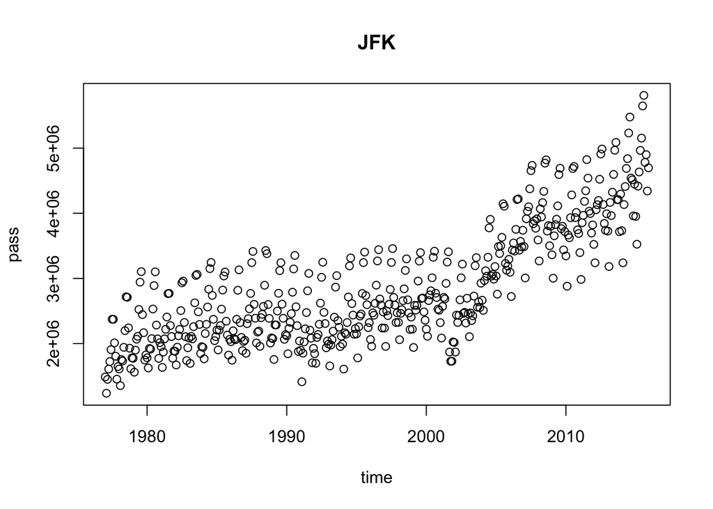

```r
JFK$time__raw=as.Date(paste(JFK$time__raw,"-01",sep=""))
plot(JFK$time__raw,JFK$series__raw,xlab="time",ylab="pass",main="JFK")
```

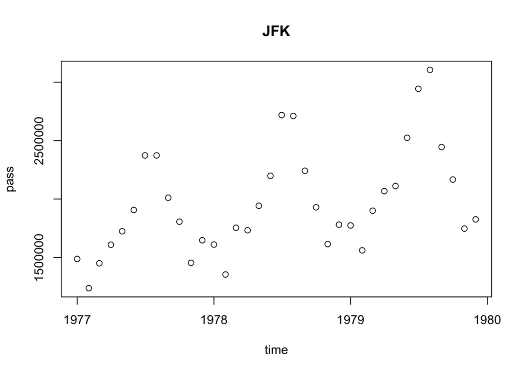

```r
plot(JFK$time__raw[1:36],JFK$series__raw[1:36],xlab="time",ylab="pass",main="JFK")
```

## 7) GDP, INFLATION & UNEMPLOYMENT (US)

**Source.** https://fred.stlouisfed.org/series/A939RX0Q048SBEA#

More information is available on the website.

**Task.** Fit suitable time series models for one or more of the series, analyzed separately. For example, you may consider AR, MA, ARMA, or GARCH models. If you use more than one model, compare the models using suitable information criteria, such as BIC, DIC, or WAIC.

You may also consider multivariate time series models, such as a simple VAR(1) model. In this case, please ask the instructor for further information.

The website also provides information on U.S. recession years. You may try to fit a switching model with two regimes: recession and non-recession.

```r
rm(list=ls())

# New Family Houses Sold: United States
# __Source.__ https://fred.stlouisfed.org/series/HSN1F

data = read.csv("data/GDP-CPI-UNE.csv",header=T)
data$DATE = as.Date(data$observation_date)
sum(is.na(data$A939RX0Q048SBEA_PCH))
```

```
## [1] 1
```

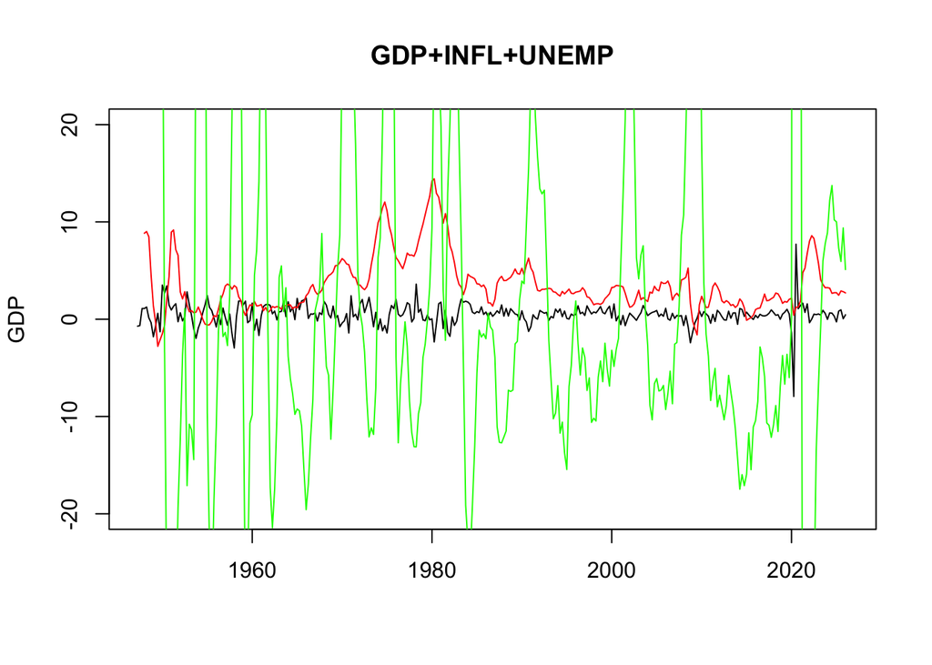

```r
plot(data$DATE,data$A939RX0Q048SBEA_PCH,type="l",xlab="",ylab="GDP",main="GDP+INFL+UNEMP",ylim=c(-20,20))
lines(data$DATE,data$CPIAUCSL_PC1,type="l",col="red")
lines(data$DATE,data$UNEMPLOY_PC1,type="l",col="green")
```

## 8) ARPA: air quality.

Data **Source.** ARPA Lombardia Open Data Portal https://www.dati.lombardia.it/stories/s/auv9-c2sj

Air quality data collected at the Milano Pascal Città Studi monitoring station (station ID: 705):

**Task.** Choose one of the following tasks.

Task 1.  
Perform a suitable regression analysis for either:

-PM10 (integer-valued response), or

-BioAz (continuous response),

using the remaining variables as covariates.

Note that the dataset also includes the day of the year (giorno), which may be useful for capturing seasonal effects.

Task 2. Consider a time series model for either PM10 or BioAz. You may:

-use a simple model without exogenous covariates, or -include the other variables as exogenous covariates.

Again, note that the dataset also includes the day of the year (giorno), which may help account for seasonality.

```r
rm(list=ls())
#
data = data.frame(read.csv("data/ARPA.csv", header=FALSE))
names=data[1,]
data=data[-1,]
colnames(data)<-names
head(data)
```

|  | Giorno | BioAZ | PM10 | precipitazioni | vento | temper | umidita |
| --- | --- | --- | --- | --- | --- | --- | --- |
| 2 | 2021-01-01 | 46.1958333333333 | 51 | 0.0727272727272727 | 1.05993006993007 | 3.27769230769231 | 90.3636363636364 |
| 3 | 2021-01-02 | 50.1916666666667 | 15 | 0.136111111111111 | 1.07458333333333 | 4.99034722222222 | 98.1944444444444 |
| 4 | 2021-01-03 | 29.2083333333333 | 14 | 0.0361111111111111 | 1.13131944444444 | 6.40951388888889 | 92.2847222222222 |
| 5 | 2021-01-04 | 35.5541666666667 | 14 | 0.0527777777777778 | 1.18055555555556 | 6.295 | 92.2083333333333 |
| 6 | 2021-01-05 | 36 | 18 | 0.0125 | 1.39555555555556 | 5.23145833333333 | 89.8888888888889 |
| 7 | 2021-01-06 | 31.5916666666667 | 12 | 0.0222222222222222 | 1.18541666666667 | 3.87 | 91.6458333333333 |

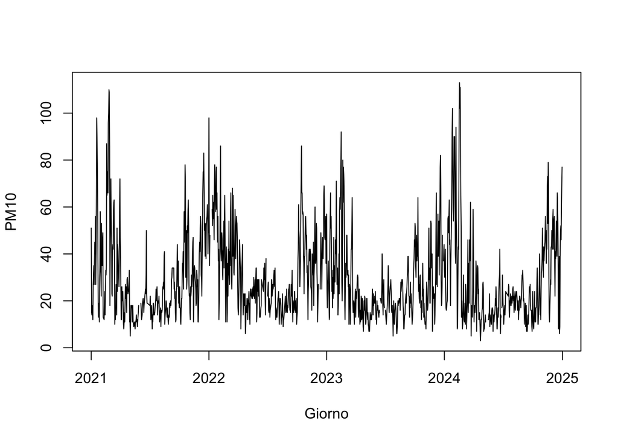

```r
data$Giorno<-as.Date(data$Giorno)
data$BioAZ<-as.numeric(data$BioAZ)
data$PM10<-as.numeric(data$PM10)
data$precipitazioni<-as.numeric(data$precipitazioni)
data$vento<-as.numeric(data$vento)
data$temper<-as.numeric(data$temper)
data$umidita<-as.numeric(data$umidita)

plot(data$Giorno, data$PM10,
     type = "l",
     xlab = "Giorno",
     ylab = "PM10")
```

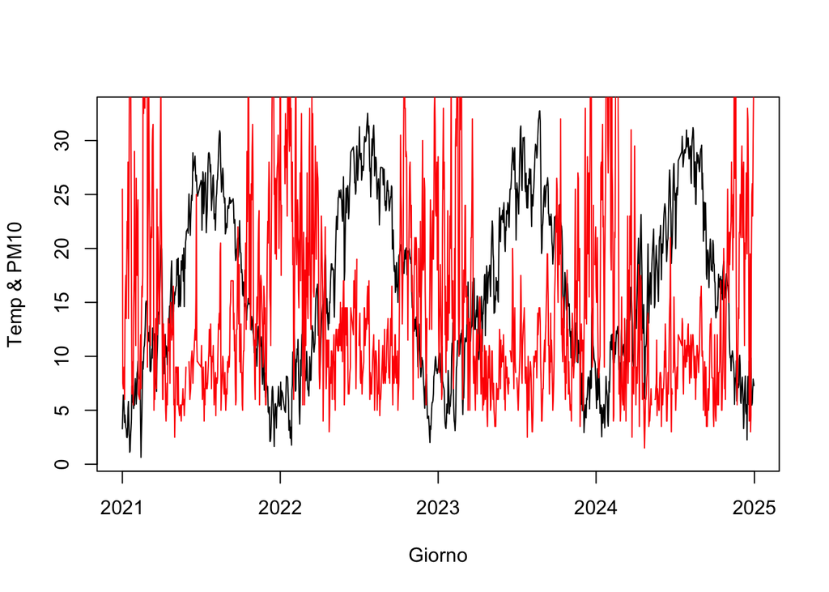

```r
plot(data$Giorno, data$temper,
     type = "l",
     xlab = "Giorno",
     ylab = "Temp & PM10")
lines(data$Giorno, 0.5*data$PM10,col="red")
```

## 9) SPF

**Source.** Federal Reserve.

**Data.** The Survey of Professional Forecasters (SPF) collects forecasts of macroeconomic variables. Both the U.S. SPF and the ECB-SPF ask forecasters to provide point forecasts and density forecasts. Density forecasts are reported in the form of histograms over a set of intervals specified in the survey instrument.

“H” horizon

“period” 0 corresponds to 10 bin, 1 to 11 bin

“YEAR” year

“QUARTER” quarter

“ID” forecaster id.

“INDUSTRY” forecaster type

“bin1” “bin2” “bin3” “bin4”  
“bin5” “bin6” “bin7” “bin8” “bin9”  
“bin10” “bin11” probability given to the bin (to be ignored)

“nbin_tot” number of bins used

“openL” “openR” 1 the forecaster gives positive probability to open (left/right) bin

“n.b.mode” position of the mode (wrt to bin number)

“prob.mode” probability assigned to the modal bin

“mode” value of the mode (unform model fitting)

“mean” value of the mean (unform model fitting)

“var” value of the variance (unform model fitting)

“median” value of the median (unform model fitting)

```r
rm(list=ls())
GDP=read.csv("data/SPF_GDP.csv")
head(GDP)
```

|  | X | H | period | YEAR | QUARTER | ID | INDUSTRY | bin1 | bin2 | bin3 | bin4 | bin5 | bin6 | bin7 | bin8 | bin9 | bin10 | bin11 | nbin_tot | openL | openR | n.b.mode | prob.mode | mode | mean | var | median |
| --- | --- | --- | --- | --- | --- | --- | --- | --- | --- | --- | --- | --- | --- | --- | --- | --- | --- | --- | --- | --- | --- | --- | --- | --- | --- | --- | --- |
| 1 | 3852 | 1 | 0 | 1992 | 1 | 20 | 2 | 0 | 0 | 0.0 | 0.00 | 0.00 | 0.5 | 0.5 | 0.00 | 0 | 0 | NA | 0.2 | 0 | 0 | 2 | 0.5 | 1.0 | 1.00 | 0.3333333 | 1.000000 |
| 2 | 3853 | 1 | 0 | 1992 | 1 | 30 | 3 | 0 | 0 | 0.1 | 0.60 | 0.30 | 0.0 | 0.0 | 0.00 | 0 | 0 | NA | 0.3 | 0 | 0 | 1 | 0.6 | 3.5 | 3.30 | 0.4433333 | 3.333333 |
| 3 | 3854 | 1 | 0 | 1992 | 1 | 35 | 2 | 0 | 0 | 0.1 | 0.10 | 0.20 | 0.5 | 0.1 | 0.00 | 0 | 0 | NA | 0.5 | 0 | 0 | 1 | 0.5 | 1.5 | 2.10 | 1.3233333 | 1.800000 |
| 4 | 3856 | 1 | 0 | 1992 | 1 | 60 | 2 | 0 | 0 | 0.0 | 0.00 | 0.05 | 0.6 | 0.3 | 0.05 | 0 | 0 | NA | 0.4 | 0 | 0 | 1 | 0.6 | 1.5 | 1.15 | 0.5108333 | 1.250000 |
| 5 | 3857 | 1 | 0 | 1992 | 1 | 62 | 2 | 0 | 0 | 0.0 | 0.05 | 0.20 | 0.5 | 0.2 | 0.05 | 0 | 0 | NA | 0.5 | 0 | 0 | 1 | 0.5 | 1.5 | 1.50 | 0.8833333 | 1.500000 |
| 6 | 3858 | 1 | 0 | 1992 | 1 | 65 | 1 | 0 | 0 | 0.0 | 0.00 | 0.10 | 0.8 | 0.1 | 0.00 | 0 | 0 | NA | 0.3 | 0 | 0 | 1 | 0.8 | 1.5 | 1.50 | 0.2833333 | 1.500000 |

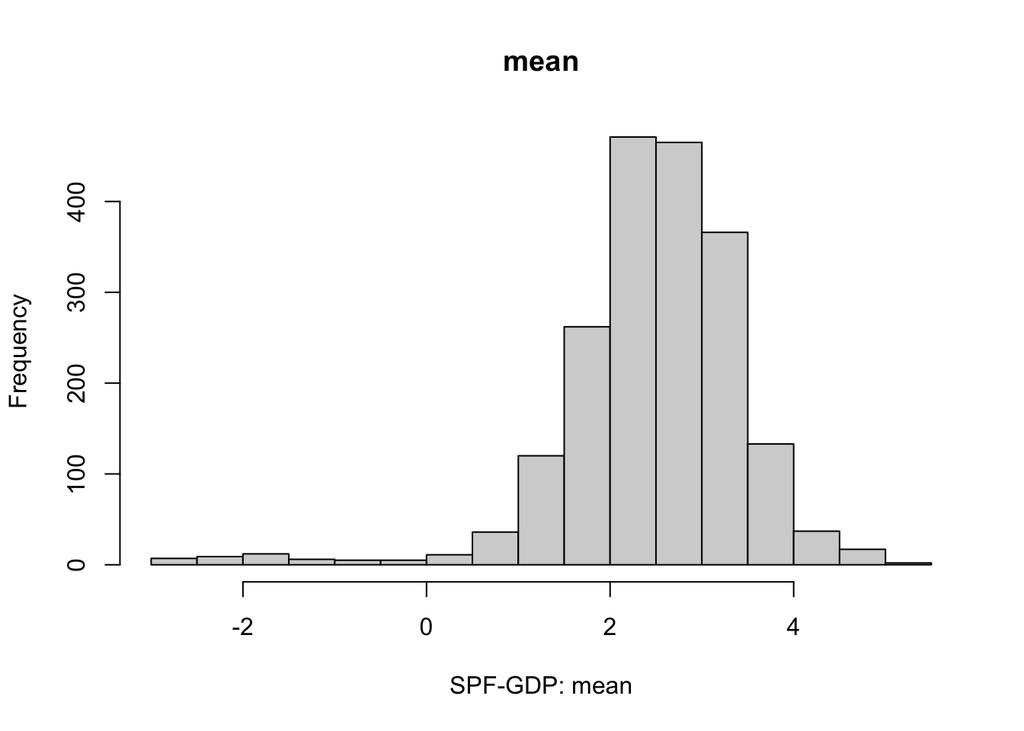

```r
GDP_B=GDP[GDP$QUARTER==1,]
Ydata=GDP_B[,c("mean","YEAR","ID")]  # select the variable of interest
hist(Ydata$mean,main="mean",xlab="SPF-GDP: mean")
```

**Task.** Investigate whether individual uncertainty appears to be associated mainly with respondent-specific effects, while point forecasts (e.g., mean or median forecasts) are more strongly affected by time-period effects.

In other words, the goal is to study whether there are substantial differences across forecasters in the confidence attached to their predictions, while each forecaster’s confidence evolves only slowly over time.

Consider only observations corresponding to a fixed forecast horizon (e.g., horizon 1, 2, etc.). If the variable of interest is denoted by $y_{f,t}$ (for example, the forecast mean or $y=\log(\sigma)$), start with the model
$$y_{f,t} = \alpha_t + \beta_f + \epsilon_{f,t},$$
where $\alpha_t$ represents the time effect and $\beta_f$ the forecaster effect.

Compare variables related to point forecasts (e.g., mean or median forecasts) with variables related to uncertainty (e.g., variance or probability assigned to the modal interval).

More advanced models may also be considered. For example:

- models with time-varying error variances;
- mixture models in which forecasters are grouped into latent blocks, and responses depend only on the block membership.

Please ask the instructor for additional explanations if you are interested in this project.

## 10) Single-cell growth measurements

**Source.** Kennard, A. S., Osella, M. C., Javer, A., Grilli, J., Nghe, P., Tans, S., Cicuta, P., & Cosentino Lagomarsino, M. C. 2015. Individuality and universality in the growth-division laws of single E. coli cells. Physical Review E, 93, 012408 (ask the teacher for further details).

**Data.** The dataset `cell_wide.csv` contains single-cell morphological measurements collected from time-lapse microscopy experiments on a bacterial cell strian (`P5ori`) grown under two different culture conditions: `Glc` (Glucose) and `RDM` (Rich Defined Media). Each row corresponds to one observation of one individual cell at a given frame of the experiment.

Columns:

First column is an index uniquely identifying the cell under consideration.

`medium`: identifies the growth medium, either `Glc` or `RDM`.

`t0`, `L0`: time and length at birth (first frame of the cell’s life).

`t1`, `L1`, …, `t61`, `L61`: time and length at subsequent frames until the cell divides (last frame of the cell’s life).`The final frame is not the same for all cells, hence the presence of trailing`NA` values.

**Task.** For each cell, the length $L$ typically grows exponentially between two divisions, that is
$$L(t)=L(t_0)e^{\beta (t-t_0)}$$
where $L(t_0)$ is the length at birth time $t_0$ and $L(t)$ is the length at time $t$. Fit a model of the form
$$\log\!\left(\frac{L_i(t)}{L_i(t_0)}\right)
=
\beta_i (t-t_0) + \epsilon_{i,t}$$
with independent Gaussian errors $\epsilon_{i,t}$ and cell-specific coefficients $\beta_i$. Study the distribution of the growth rates `beta_i` across conditions. Use hierarchical modelling to share information across cells and obtain more precise estimates of the growth rates. Discuss whether the two media `GLC` and `RDM` lead to significantly different cell sizes and/or growth rates.

```r
rm(list=ls())
library(dplyr)
```

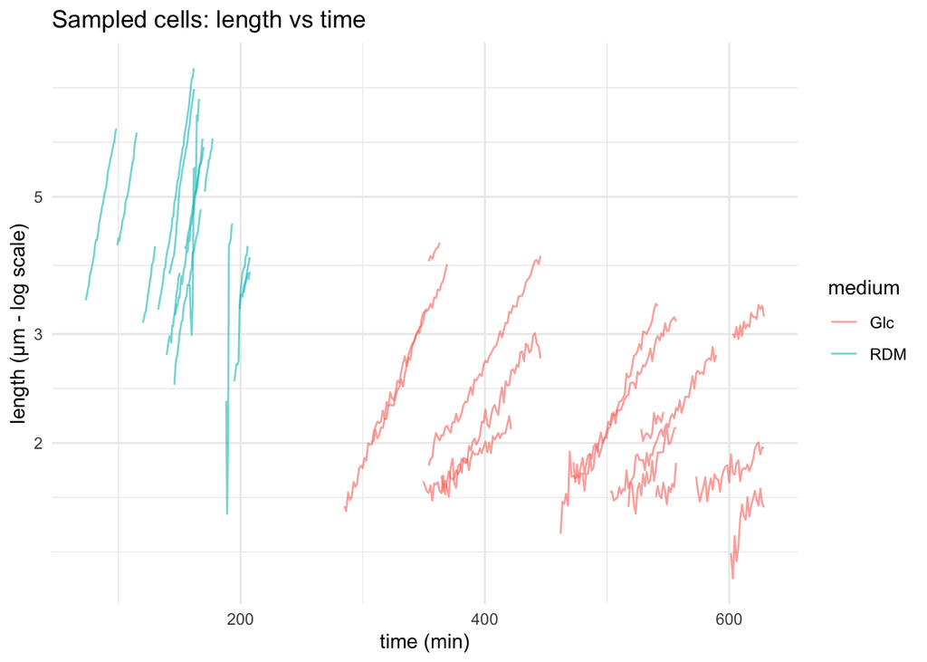

```r
library(tidyr)
library(ggplot2)
wide <- read.csv("data/cells_wide.csv", row.names = 1, check.names = FALSE,
                 stringsAsFactors = FALSE)

wide %>%
  tibble::rownames_to_column("CID") %>%
  pivot_longer(
    cols = -c(CID, medium),
    names_to = c(".value", "i"),
    names_pattern = "([tL])(\\d+)"
  ) %>%
  rename(time = t, length = L) %>%
  filter(!is.na(time), !is.na(length)) %>%
  ggplot(aes(x = time, y = length, group = CID, colour = medium)) +
  geom_line(alpha = 0.6) +
  scale_y_log10() +
  labs(title = "Sampled cells: length vs time",
       x = "time (min)", y = "length (µm - log scale)") +
  theme_minimal()
```

## 11) Hourly city load factor

**Source** Salam & El Hibaoui, *Power Consumption of Tetouan City*, UCI Machine Learning Repository, https://archive.ics.uci.edu/dataset/849/power+consumption+of+tetouan+city. The original release records the active power consumed by the three distribution zones of Tetouan (Morocco) during 2017, sampled every ten minutes by the SCADA system of the local utility.

**Data.** Data file: `data/hourly_load_factor.csv` (2000 rows). The CSV we share is a derived, pre-cleaned version. For each (day, hour) of the year we have computed the hourly mean of the **city-wide** active power $\overline{P}(d, h) = \mathrm{Zone1}(d, h) + \mathrm{Zone2}(d, h) + \mathrm{Zone3}(d, h)$ from the original 10-min readings, and then the **hourly load factor**
$$\mathrm{LF}(d, h) = \frac{\overline{P}(d, h)}{\max_{h'}
\overline{P}(d, h')}\,,$$
i.e. the ratio between the average load in hour $h$ and the highest hourly average of the same day. By construction $\mathrm{LF}(d, h) \in [0, 1]$: the day-peak hour gets exactly $1$ and the deepest off-peak hour gets the smallest value. From the full $365 \times 24 \approx 8700$ (day, hour) cells we have taken a uniform random subsample of 2000 rows and clamped the values to $(10^{-3},\, 1 - 10^{-3})$ so that the Beta log-density is finite at the boundary.

Variables:

`date` : calendar date (M/D/YYYY).

`hour` : hour of the day, integer in $\{0, \dots, 23\}$.

`load_factor` : hourly load factor as defined above, in $(10^{-3},\, 1 - 10^{-3})$.

**Task.**

1. Compare a single Beta vs Beta mixture model with $H = 1, 2, 3, 4, 5$, with model selection via WAIC.
2. Overlay the posterior predictive density on the empirical histogram and verify that the modes are recovered.
3. **Post-hoc exploration.** Assign each observation to its maximum-a-posteriori component, then plot the empirical fraction of observations in each component as a function of `hour`.
4. **Advanced.** Fit a second model which does classification on `hour` using the component assignment as response variable, and plot the predicted probability of each component as a function of `hour`. Do the two plots match? Discuss the results. (Details for this step are presented in the additional details notebook) We will predict the component assignment using a multinomial logistic regression with the Fourier-transformed `hour` as covariate, i.e. with predictors $\sin(k 2\pi h / 24)$ and $\cos(k 2\pi h / 24)$ to capture the periodicity of the day.

```r
rm(list=ls())
lf = read.csv("data/hourly_load_factor.csv")
dim(lf); head(lf); summary(lf$load_factor)
```

```
## [1] 2000    3
```

|  | date | hour | load_factor |
| --- | --- | --- | --- |
| 1 | 3/18/2017 | 0 | 0.67677 |
| 2 | 1/18/2017 | 1 | 0.53322 |
| 3 | 7/7/2017 | 18 | 0.75073 |
| 4 | 6/17/2017 | 4 | 0.61787 |
| 5 | 6/2/2017 | 9 | 0.58899 |
| 6 | 4/6/2017 | 6 | 0.51257 |

```
##    Min. 1st Qu.  Median    Mean 3rd Qu.    Max.
##  0.4257  0.5860  0.7329  0.7235  0.8042  0.9990
```

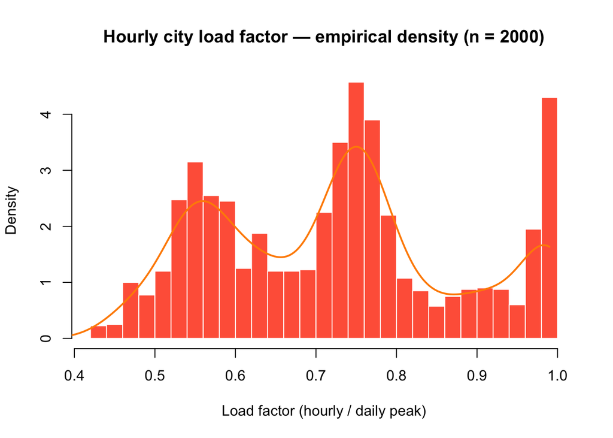

```r
hist(lf$load_factor, breaks = 35, freq = FALSE,
     col = "tomato", border = "white",
     xlab = "Load factor (hourly / daily peak)",
     main = "Hourly city load factor — empirical density (n = 2000)")
lines(density(lf$load_factor, from = 0.01, to = 0.99),
      col = "darkorange", lwd = 2)
```

## 12) Capacitor accelerated life tests (survival data)

**Source.** Dataset `capacitor` from the R package `survival`.

**Data.** The dataset contains the result of 64 accelerated life tests on capacitors. The experiment follows a 4 x 2 factorial design over two stress variables:

`voltage`: the operating voltage during the test (4 levels);

`temperature`: the operating temperature during the test in degrees Celsius (2 levels — must be converted to Kelvin for the physical model);

`time`: observed time of failure (or censoring time), in hours;

`status`: censoring indicator (1 = failure observed, 0 = right-censored).

**Task.** A commonly used physical hazard model for capacitor failure is
$$h(t \mid V, T) \;\propto\; V^{\gamma}\,\exp\!\left(-\beta / T\right),$$
with $T$ measured in Kelvin. This corresponds to a regression on $\log(V)$ and $1/T$.

```r
rm(list=ls())
# install.packages("survival") #if needed
library(survival)
data(capacitor)
head(capacitor)
```

|  | temperature | voltage | fail | time | status |
| --- | --- | --- | --- | --- | --- |
| 1 | 170 | 200 | NA | 439 | 1 |
| 2 | 170 | 200 | NA | 904 | 1 |
| 3 | 170 | 200 | NA | 1092 | 1 |
| 4 | 170 | 200 | NA | 1105 | 1 |
| 5 | 170 | 250 | NA | 572 | 1 |
| 6 | 170 | 250 | NA | 690 | 1 |

```r
dim(capacitor)
```

```
## [1] 64  5
```

```r
# Convert temperature to Kelvin for the physical model
capacitor$tempK = capacitor$temperature + 273.15

# Quick look at the design
table(capacitor$voltage, capacitor$temperature)
```

```
##
##       170 180
##   200   8   8
##   250   8   8
##   300   8   8
##   350   8   8
```

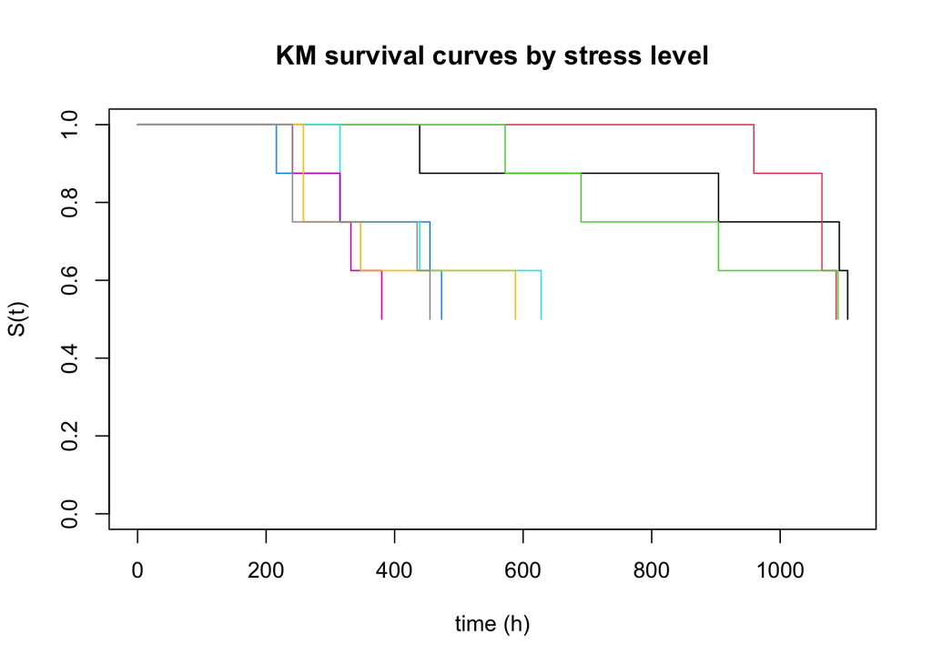

```r
# Kaplan-Meier curves stratified by stress level
fit_km = survfit(Surv(time, status) ~ voltage + temperature, data = capacitor)
plot(fit_km, col = 1:8, xlab = "time (h)", ylab = "S(t)",
     main = "KM survival curves by stress level")
```